# Irec and creel data exploration

Catarina Wor

October 2021

# 1 Background

We propose to develop a calibration model to combine both survey methods to a single recreational catch estimate, taking into account month and area.

I am thinking this would be a state-space mode as we have error associated with both surveys, something like:

The simple model (one currently being used):

$$\begin{align}
&iREC_i = \beta_1\cdot z_i + \epsilon_i\\
&z_i = Creel_i + \nu_{i}
\end{align}$$

$$\begin{align}
&\epsilon_i \sim N(0,\sigma_{\epsilon})\\
&\nu_{i} \sim N(0,\sigma_{\nu})
\end{align}$$

where:

$iREC_i$ = iREC observation

$Creel_i$ = creel observation

$\beta_1$ = slope associated with $Creel_i$

$z_i$ = smoothed (‘true’) $Creel_i$

$\epsilon_i$ and $\nu_{i}$ are random normal variables

Adding area and month:

$$\begin{align}
&iREC_i = \beta_1\cdot z_i + \beta_2\cdot area_i + \beta_3\cdot month_i + \epsilon_i\\
&z_i = Creel_i + \nu_{i}
\end{align}$$

$$\begin{align}
&\epsilon_i \sim N(0,\sigma_{\epsilon})\\
&\nu_{i} \sim N(0,\sigma_{\nu})
\end{align}$$

where: $\beta_2$ = slope associated with area

$area_i$ = area for each observation (categorical)

$\beta_3$ = slope associated with month

$month_i$ = month for each observation (cyclic variable?)

**A few notes on the current data:**

- The creel data does not include the quality control, e.g. creel data for september may only include estimates up to labour day. - Rob and I will get together and discuss a few quality control scenarios, but I wanted to disribute this before our meeting.
- iRec data was inputed: any missing observations were inputed with 0’s. If no survey respondant said they caught a chinook, then our estimate is 0.
- If there is any particular plot that you would like to see, let me know.

# 2 Relationships between creel and irec

## 2.1 Relationship by month

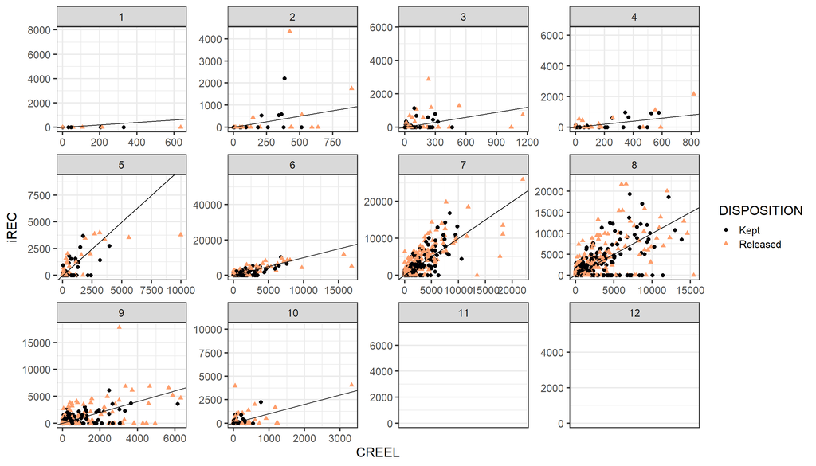

# 3 Relationship by area

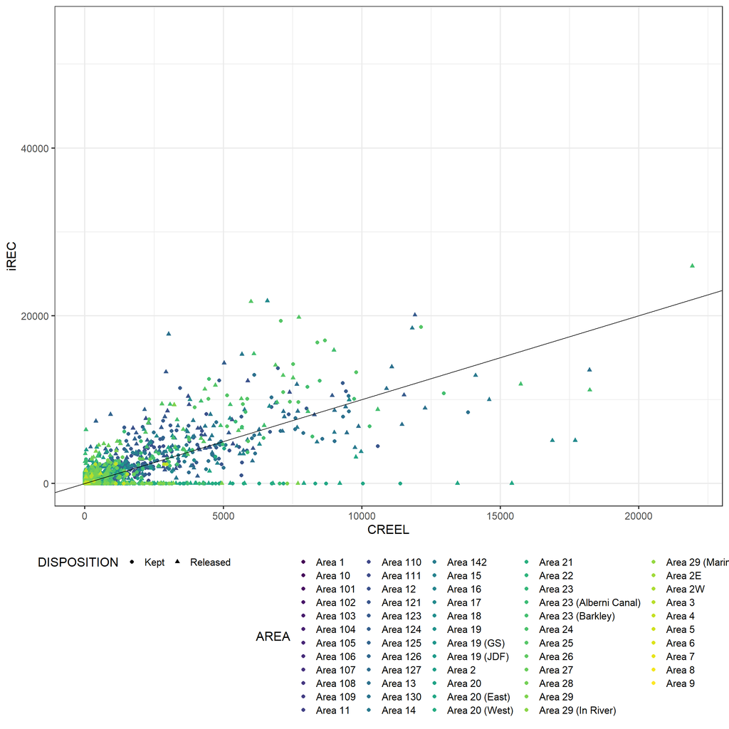

# 4 Relationship by year

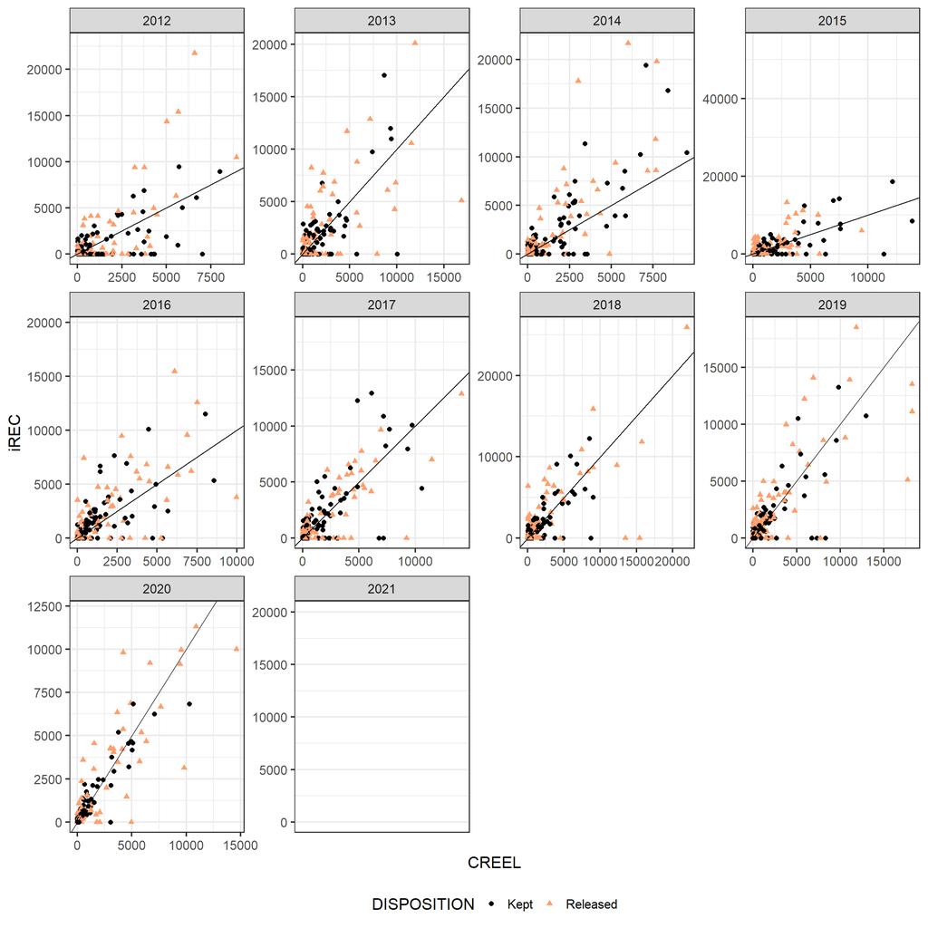

## 4.1 iRec:creel ratio by month

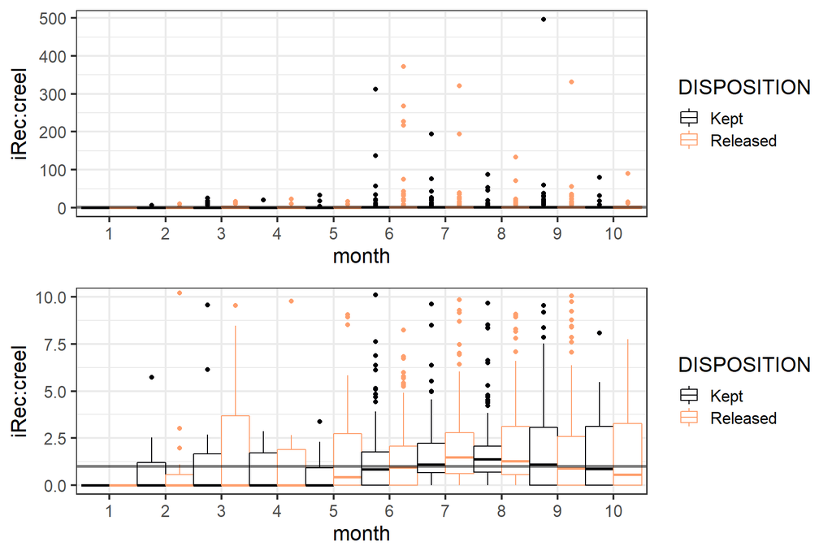

## 4.2 iRec:creel ratio by area

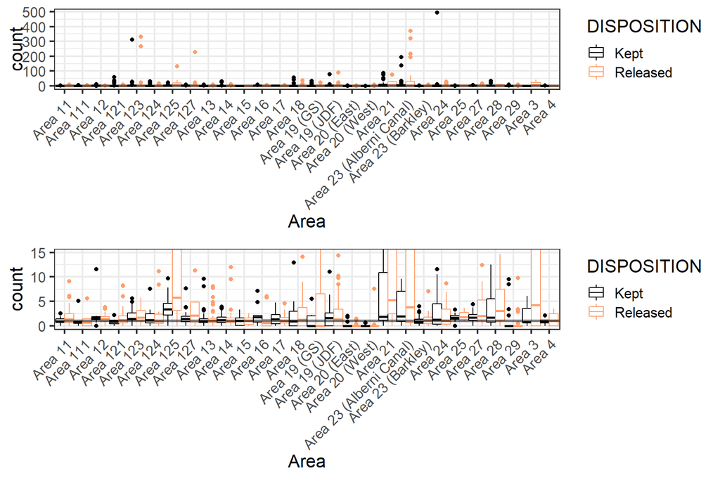

**The year figure seems to suggest that 2012 and 2013 were different from all the other years, Perhaps people were still getting used to irec?**

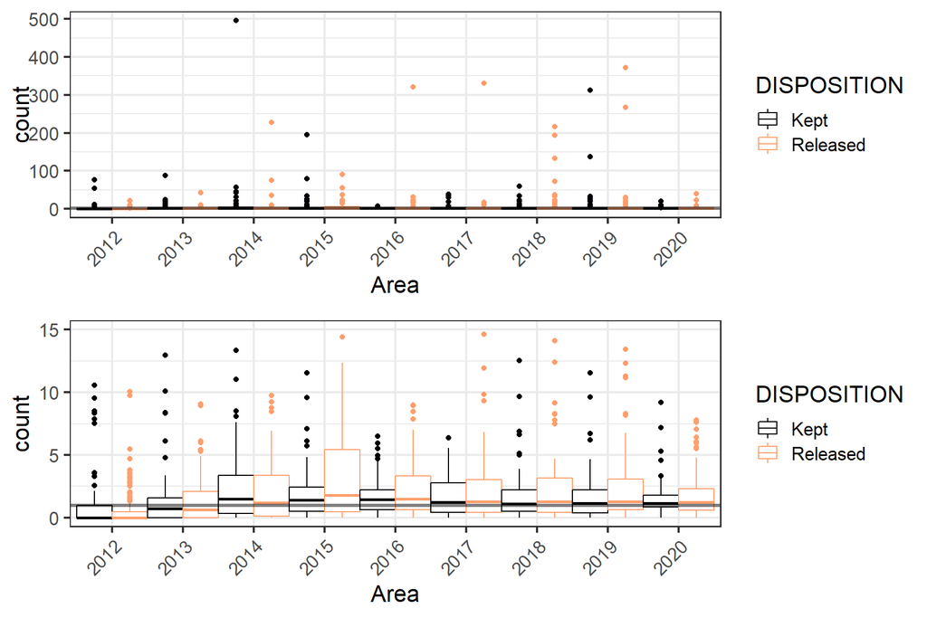

# 5 Data distribution

Creel estimates are incomplete. How would there missing values affect the model fit?

## 5.1 Observation counts by month

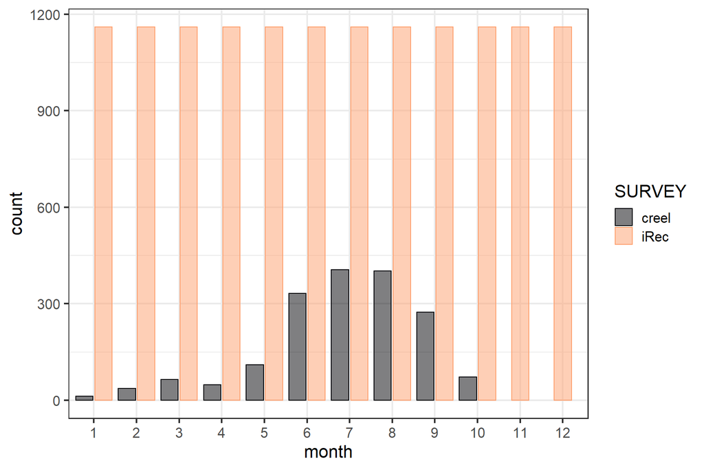

Figure 5.1: Observation counts for creel and iRec by month. Note: iRec values were inputed, as the absence of a response implies zero catch.

## 5.2 Observation counts by area

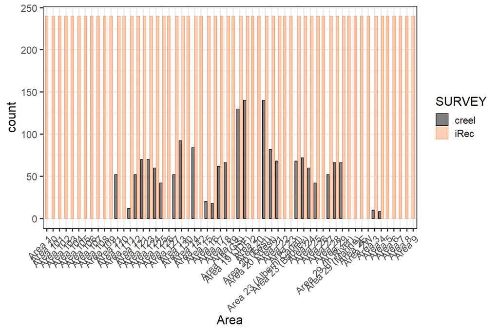

Figure 5.2: Observation counts for creel and iRec by area. Note: iRec values were inputed, as the absence of a response implies zero catch.

## 5.3 Observation counts by year

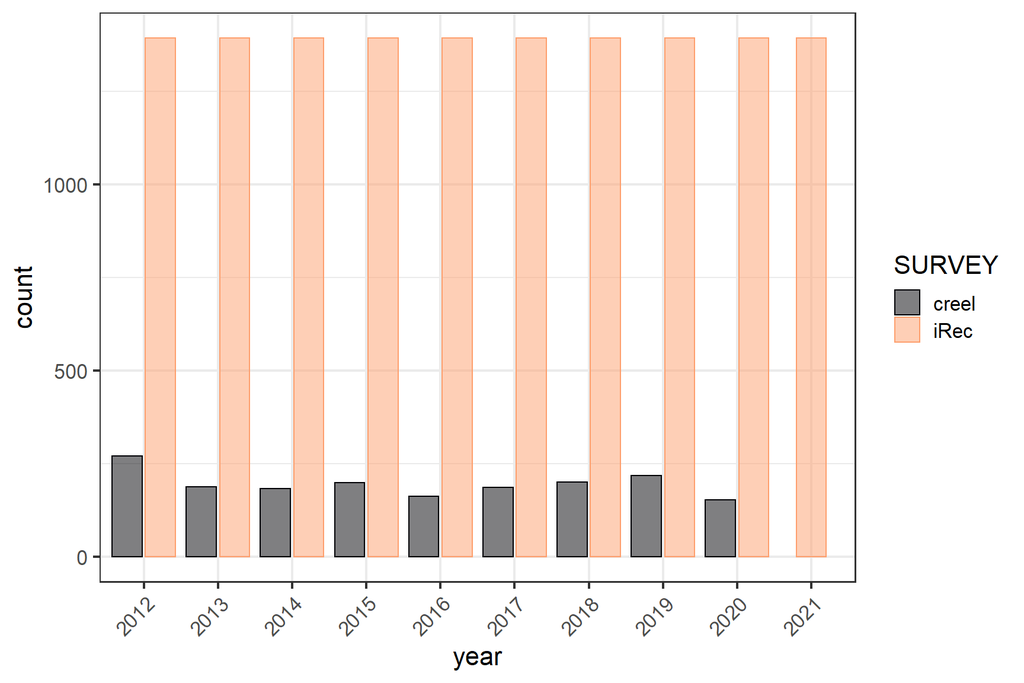

Figure 5.3: Observation counts for creel and iRec by year. Note: iRec values were inputed, as the absence of a response implies zero catch.

## 5.4 sum of estimates by month

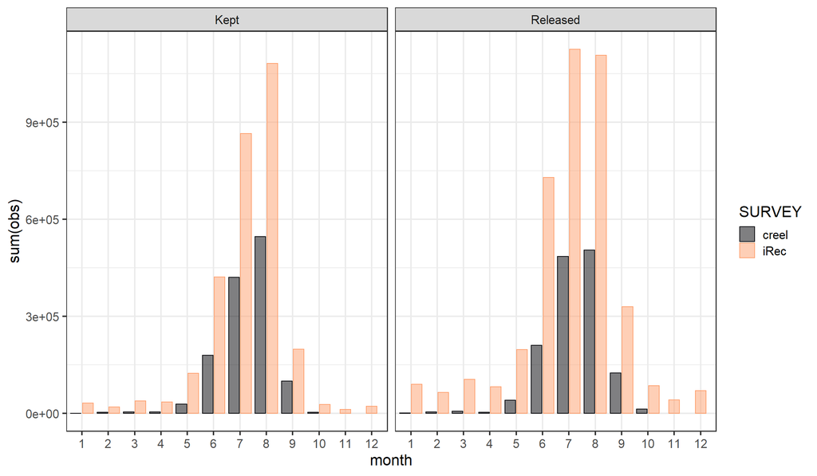

Figure 5.4: Sum of estimates for creel and iRec by month. Note: iRec values were inputed, as the absence of a response implies zero catch.

## 5.5 sum of estimates by area

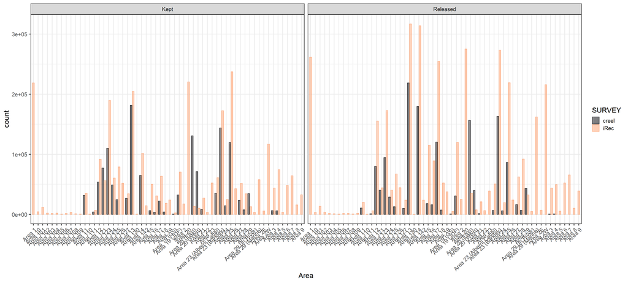

Figure 5.5: Sum of estimates for creel and iRec by area. Note: iRec values were inputed, as the absence of a response implies zero catch.

## 5.6 sum of estimates by year

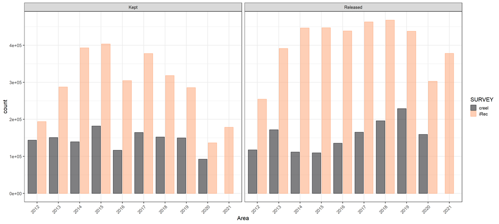

Figure 5.6: Sum of estimates for creel and iRec by year. Note: iRec values were inputed, as the absence of a response implies zero catch.

# 6 Background

We propose to develop a calibration model to combine both survey methods to a single recreational catch estimate, taking into account month and area.

I am thinking this would be a state-space mode as we have error associated with both surveys, something like:

The simple model (one currently being used):

$$\begin{align}
&iREC_i = \beta_1\cdot z_i + \epsilon_i\\
&z_i = Creel_i + \nu_{i}
\end{align}$$

$$\begin{align}
&\epsilon_i \sim N(0,\sigma_{\epsilon})\\
&\nu_{i} \sim N(0,\sigma_{\nu})
\end{align}$$

where:

$iREC_i$ = iREC observation

$Creel_i$ = creel observation

$\beta_1$ = slope associated with $Creel_i$

$z_i$ = smoothed (‘true’) $Creel_i$

$\epsilon_i$ and $\nu_{i}$ are random normal variables

Adding area and month:

$$\begin{align}
&iREC_i = \beta_1\cdot z_i + \beta_2\cdot area_i + \beta_3\cdot month_i + \epsilon_i\\
&z_i = Creel_i + \nu_{i}
\end{align}$$

$$\begin{align}
&\epsilon_i \sim N(0,\sigma_{\epsilon})\\
&\nu_{i} \sim N(0,\sigma_{\nu})
\end{align}$$

where: $\beta_2$ = slope associated with area

$area_i$ = area for each observation (categorical)

$\beta_3$ = slope associated with month

$month_i$ = month for each observation (cyclic variable?)

## 6.1 Questions about model formulation:

**Q - Which parametes should be treated as “random”? Should I set $z_i$ as a random parameter?**

**Q- should I consider using a hyper prior on area? And treat it as a random effect?**

**Q - I am not sure of how to account for missing months (if I have no creel data in winter months).**

**Q - Month as a cyclic variable? Using cyclic splines? maybe not a good idea give the plot of ratios by months**

**Q - All estimates os iRec and creel have sds associated with them. We could weight the observations with cvs, as we do in survey indexes in stock assessment models. Suggestions?**

**Q - Interaction terms with area and month?**

It is true that interactions by area and month may exist. But I am not sure I have enough data to estimate it? maybe consider a full model with the interactions?

**Q - Consider year as a covariate?**

iRec response rates and response quality may have improved over the years as users became more familiar with the interface. I don’t think we would have enough observations to consider year, area and month. But maybe if we drop month we could include year? Or we could aggregate the years into blocks, e.g. pre and pos 2017.

**Q - Which program to use? TMB, Stan, brms, rstanarm, or glmmTMB**

I think we are inclined to use a Bayesian framework. Depending on who will be using this model, they might use a s ingle point or credible intervals, it would be good to have the option.

glmmTMB - I am not sure we can get Bayesian estimates with it? maybe I’m wrong? TMB(stan) - I already know. Stan,brms, rstanarm - I am not super knowledgeable of it but keen to learn.

Basically I am flexible, but I might need more help depending on the program we choose.

**Q - Spatial covariance?**

Can we account for spatial covariance if areas are discrete units (i.e. PFMA) and not continuous? How would we inform the model that Area 18 and 29 are neighbors? See [the PFMA maps](https://www.pac.dfo-mpo.gc.ca/fm-gp/maps-cartes/areas-secteurs/index-eng.html)

**Q- spline on month estimates: this might not be relevant based on plots of the ratio between iRec and creel estimates. But interested in your thoughts.**